# Exploratory Graphs

## Missing values and plots

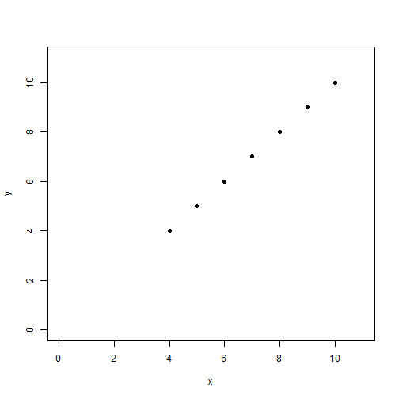

```r
x <- c(NA, NA, NA, 4, 5, 6, 7, 8, 9, 10)
y <- 1:10
plot(x, y, pch = 19, xlim = c(0, 11), ylim = c(0, 11))
```

NA values are skipped, pay attention to make right conclusions. You can also do a boxplot. Create all values where x < 0 to be NA and see if there's a relationship between them

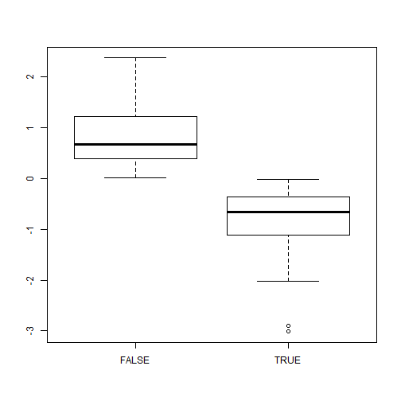

```r
set.seed(8)
x <- rnorm(100)
y <- rnorm(100)
y[x < 0] <- NA
boxplot(x ~ is.na(y))
```

From this we can see that if y == NA, x values are small and when y != NA, x values are big.

# Expository Graphs

Those are the graphs included in final analysis.

## Axes

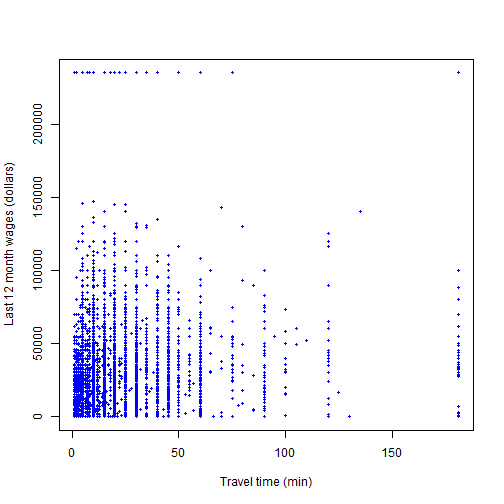

```r
plot(pData$JWMNP, pData$WAGP, pch = 19, col = "blue", cex = 0.5, xlab = "Travel time (min)",
    ylab = "Last 12 month wages (dollars)")
```

Changing size and orientation

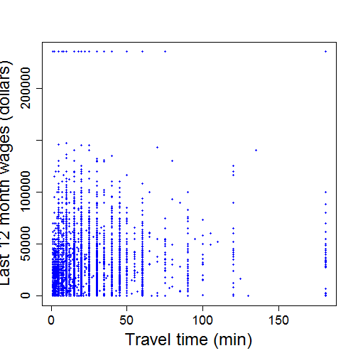

```r
plot(pData$JWMNP, pData$WAGP, pch = 19, col = "blue", cex = 0.5, xlab = "Travel time (min)",
    ylab = "Last 12 month wages (dollars)", cex.lab = 2, cex.axis = 1.5)
```

## Legends

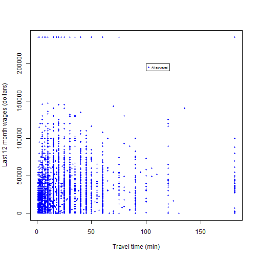

```r
plot(pData$JWMNP, pData$WAGP, pch = 19, col = "blue", cex = 0.5, xlab = "Travel time (min)",
    ylab = "Last 12 month wages (dollars)")
legend(100, 2e+05, legend = "All surveyed", col = "blue", pch = 19, cex = 0.5)
```

if more than one color

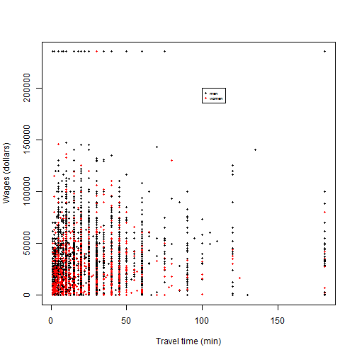

```r
plot(pData$JWMNP, pData$WAGP, pch = 19, cex = 0.5, xlab = "Travel time (min)",
    ylab = "Wages (dollars)", col = pData$SEX)
legend(100, 2e+05, legend = c("men", "women"), col = c("black", "red"), pch = c(19,
    19), cex = c(0.5, 0.5))
```

## Titles

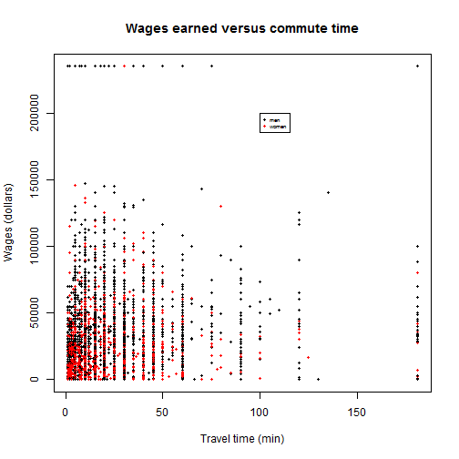

```r
plot(pData$JWMNP, pData$WAGP, pch = 19, cex = 0.5, xlab = "Travel time (min)",
    ylab = "Wages (dollars)", col = pData$SEX, main = "Wages earned versus commute time")
legend(100, 2e+05, legend = c("men", "women"), col = c("black", "red"), pch = c(19,
    19), cex = c(0.5, 0.5))
```

## Multiple panels

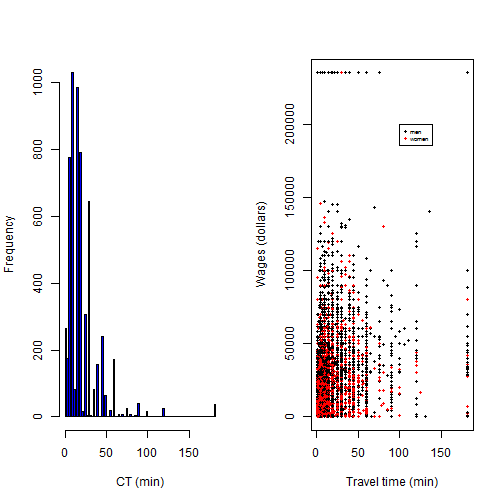

```r
# orient panels
par(mfrow = c(1, 2))
hist(pData$JWMNP, xlab = "CT (min)", col = "blue", breaks = 100, main = "")
plot(pData$JWMNP, pData$WAGP, pch = 19, cex = 0.5, xlab = "Travel time (min)",
    ylab = "Wages (dollars)", col = pData$SEX)
legend(100, 2e+05, legend = c("men", "women"), col = c("black", "red"), pch = c(19,
    19), cex = c(0.5, 0.5))
```

## Adding text

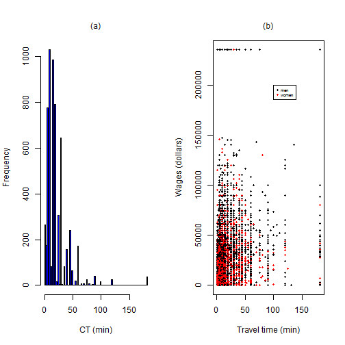

```r
# orient panels
par(mfrow = c(1, 2))
hist(pData$JWMNP, xlab = "CT (min)", col = "blue", breaks = 100, main = "")
mtext(text = "(a)", side = 3, line = 1)
plot(pData$JWMNP, pData$WAGP, pch = 19, cex = 0.5, xlab = "Travel time (min)",
    ylab = "Wages (dollars)", col = pData$SEX)
legend(100, 2e+05, legend = c("men", "women"), col = c("black", "red"), pch = c(19,
    19), cex = c(0.5, 0.5))
mtext(text = "(b)", side = 3, line = 1)
```

## Graphical Workflow

**PDF**

- params: file, height, width

```
pdf(file="twoPanel.pdf", height=480, width=(2 * 480))
par(mfrow=c(1, 2))
hist(pData$JWMNP, xlab="CT (min)", col="blue", breaks=100, main="")
mtext(text="(a)", side=3, line=1)
plot(pData$JWMNP,
     pData$WAGP,
     pch=19,
     cex=0.5,
     xlab="Travel time (min)",
     ylab="Wages (dollars)",
     col=pData$SEX)
legend(100, 200000,
       legend=c("men", "women"),
       col=c("black", "red"),
       pch=c(19, 19), cex=c(0.5, 0.5))
mtext(text="(b)", side=3, line=1)
dev.off()
```

Same for **PNG**

You can tweak graph and copy it directly to pdf

```
par(mfrow=c(1, 2))
hist(pData$JWMNP, xlab="CT (min)", col="blue", breaks=100, main="")
plot(pData$JWMNP,
     pData$WAGP,
     pch=19,
     cex=0.5,
     xlab="Travel time (min)",
     ylab="Wages (dollars)",
     col=pData$SEX)
dev.copy2pdf(file="twoPanelv2.pdf")
```